# Stats 506, F20, Problem Set 3

Zhihao Xu, xuzhihao@umich.edu

October 26, 2020

## About

This is the write-up solution to Problem Set 3 for Stats 506 in Fall 2020.

### Code Organization

- `ps3_q1.do` consists of the `stata` code used in Question 1. Please comment the `mkdir` line after the first run.
- `ps3_q2.do` consists of the `stata` code used in Question 2
- `ps3_q3.do` consists of the `stata` code used in Question 3. Please comment the `mkdir` line after the first run.
- `output` folder consists all the tables exported from `stata`, and the sub-folder `ohx` consists all the `csv` files exported from `stata` for Question 3.
- `ps3_writeup.R` imports all the data exported from `stata` stored in the `output` folder and builds the page your are reading. Code for figures and tables can be found here.

## Question 1

Here we construct the balance tables for each of the demographics required. We use chi-squared test for marginal associations between categorical variables and whether the dentition exam is complete, and t-test for continuous variable. For continuous variable, present `mean(IQR)` and for categorical variables, present `n(%)`.

### Age Under 20

#### Age

| Ohx Status | Age |
| --- | --- |
| Missing | 1.53 ( 0) |
| Complete | 9.18 (10) |
| **Test Marginal Associations** |  |
| $T$ | -57.14 (p=0.00) |

#### Gender

| Ohx Status | Male | Female | Tatal |
| --- | --- | --- | --- |
| Missing | 875 (10.97) | 887 (11.41) | 1762 (11.19) |
| Complete | 7102 (89.03) | 6889 (88.59) | 13991 (88.81) |
| Total | 7977 (100.00) | 7776 (100.00) | 15753 (100.00) |
| **Test Marginal Associations** |  |  |  |
| $\chi^2$ | 0.76 (p=0.38) |  |  |

#### Race/Ethnicity

| Ohx Status | Mexican American | Other Hispanic | Non-Hispanic White | Non-Hispanic Black | Non-Hispanic Asian | Other Race | Tatal |
| --- | --- | --- | --- | --- | --- | --- | --- |
| Missing | 400 (12.43) | 200 (11.80) | 566 (13.12) | 369 (9.49) | 108 (7.17) | 119 (10.52) | 1762 (11.19) |
| Complete | 2817 (87.57) | 1495 (88.20) | 3748 (86.88) | 3520 (90.51) | 1399 (92.83) | 1012 (89.48) | 13991 (88.81) |
| Total | 3217 (100.00) | 1695 (100.00) | 4314 (100.00) | 3889 (100.00) | 1507 (100.00) | 1131 (100.00) | 15753 (100.00) |
| **Test Marginal Associations** |  |  |  |  |  |  |  |
| $\chi^2$ | 58.22 (p=0.00) |  |  |  |  |  |  |

### Age Over 20

#### Age

| Ohx Status | Age |
| --- | --- |
| Missing | 50.26 (26) |
| Complete | 49.65 (30) |
| **Test Marginal Associations** |  |
| $T$ | 1.21 (p=0.23) |

#### Gender

| Ohx Status | Male | Female | Tatal |
| --- | --- | --- | --- |
| Missing | 538 (5.15) | 739 (6.60) | 1277 (5.90) |
| Complete | 9916 (94.85) | 10453 (93.40) | 20369 (94.10) |
| Total | 10454 (100.00) | 11192 (100.00) | 21646 (100.00) |
| **Test Marginal Associations** |  |  |  |
| $\chi^2$ | 20.66 (p=0.00) |  |  |

#### Race/Ethnicity

| Ohx Status | Mexican American | Other Hispanic | Non-Hispanic White | Non-Hispanic Black | Non-Hispanic Asian | Other Race | Tatal |
| --- | --- | --- | --- | --- | --- | --- | --- |
| Missing | 197 (6.75) | 165 (7.33) | 359 (4.52) | 283 (5.71) | 241 (8.61) | 32 (4.10) | 1277 (5.90) |
| Complete | 2722 (93.25) | 2086 (92.67) | 7585 (95.48) | 4670 (94.29) | 2558 (91.39) | 748 (95.90) | 20369 (94.10) |
| Total | 2919 (100.00) | 2251 (100.00) | 7944 (100.00) | 4953 (100.00) | 2799 (100.00) | 780 (100.00) | 21646 (100.00) |
| **Test Marginal Associations** |  |  |  |  |  |  |  |
| $\chi^2$ | 81.25 (p=0.00) |  |  |  |  |  |  |

#### Education Level

| Ohx Status | Some college/College graduate | No college/Unknown | Tatal |
| --- | --- | --- | --- |
| Missing | 641 (6.28) | 636 (5.56) | 1277 (5.90) |
| Complete | 9563 (93.72) | 10806 (94.44) | 20369 (94.10) |
| Total | 10204 (100.00) | 11442 (100.00) | 21646 (100.00) |
| **Test Marginal Associations** |  |  |  |
| $\chi^2$ | 5.08 (p=0.02) |  |  |

## Question 2

In this question, we tried to fit the logistic regression model about whether an NHANES participant has a complete dentition exam conditional on the demographics include in the Question 1. We tried some different models like using quadratic or cubic function of `age`, and considering interactions between each predictor. The final model we choose is `c.age##c.age##i.u20 i.riagendr i.n_edu` with AIC `14951.27`.

#### Regression Table of Final Model

| Parameter | Coef. | Std. Err. | z | P>\|z\| | lwr | upr |
| --- | --- | --- | --- | --- | --- | --- |
| age | -0.0426617 | 0.0105793 | -4.03 | 0.000 | -0.0633968 | -0.0219267 |
| c.age#c.age | 0.0004042 | 0.0001032 | 3.92 | 0.000 | 0.0002019 | 0.0006066 |
| u20 |  |  |  |  |  |  |
| <20 | -4.7013530 | 0.2601693 | -18.07 | 0.000 | -5.2112760 | -4.1914310 |
| u20#c.age |  |  |  |  |  |  |
| <20 | 1.5796840 | 0.0384756 | 41.06 | 0.000 | 1.5042730 | 1.6550950 |
| u20#c.age#c.age |  |  |  |  |  |  |
| <20 | -0.0726282 | 0.0019523 | -37.20 | 0.000 | -0.0764546 | -0.0688018 |
| 2.riagendr | -0.1797175 | 0.0448959 | -4.00 | 0.000 | -0.2677119 | -0.0917231 |
| n_edu |  |  |  |  |  |  |
| Some college/College graduate | 0.1174599 | 0.0579192 | 2.03 | 0.043 | 0.0039403 | 0.2309795 |
| _cons | 3.8076930 | 0.2563110 | 14.86 | 0.000 | 3.3053320 | 4.3100530 |

#### AIC

| Model | AIC |
| --- | --- |
| c.age i.riagendr i.n_edu | 20460.93 |
| cc.age##c.age i.riagendr i.n_edu | 19349.04 |
| cc.age##c.age##i.riagendr i.n_edu | 19337.29 |
| c.age##c.age i.riagendr i.n_edu i.u20 | 18342.69 |
| c.age##c.age##i.u20 i.riagendr i.n_edu | 14951.27 |

## Question 3

In this question, we tried to investigate the relationship between each teeth’s status and age, and quantify how teeth progress as we age. Here we construct a big figure to present our findings. Through the following figure, we can see that when age is under 6, the proportion of `Primary tooth (delicious) present` and `Tooth not present` is relatively high. And, these two proportions are decreasing sharply as age increases, which is decreased to around 0 when age is greater than 12. For the proportion of `Permanent tooth present`, it is close to 0 when age is less than 6, and increases when age is from 6 to 12 depends on the teeth number. After the age is greater than 18, this proportion starts to slightly decrease as age increases. The proportion of `Dental implant` and `Permanent dental root fragment` are very close to 0 when age is less than 18, and increase after that. Compared to other proportions, the confidence interval of these two proportions are relatively large, especially for `Dental implant`, which indicates that the diversity of `Dental implant` level is quite large compared with other levels.

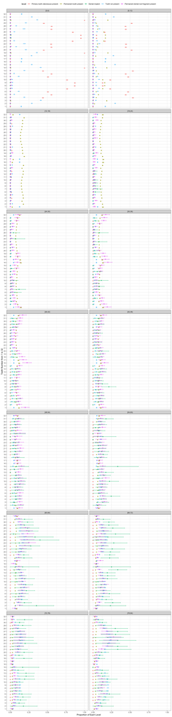

**Figure 1.** Porportion of Each Teeth’s Status Level by Age